# CSX Midterm Project

graduatecrisis

2018年11月22日

## Analysis of The Game Award – GOTY

This project is to anaylze games which are nominated for Game of the Year(GOTY) by The Game Award. We would like to see if there exists a suitable cluster analysis method which we use to conclude the shared traits among winners. In this project we would approach the problem with 3 perspectives:

- **Nature & Attributes of the Game**
  - Basic information: Studio, Publisher, Themes, Gamingtime…etc.
- **Professional Critcs’ Ratings & Review**
  - Influential media reviews: Polygon, IGN, GameRatings…etc
- **Players’ Ratings & Review**
  - Player’s feedback on *Metacritics*

**Project Goals:**

- What are the traits for the award-wining games?
- What makes them different from other nominees?

**Analysis Approach:**

- *Cluster Analysis & Unsupervised Learning(PCA)*
- *Text Mining*
- *Data Visualization*

**Analysis Structure:**

1. EDA - Data Overview
2. Cluster Analysis - From Aspect of Games, Critics & Players
3. Cluster Comparison & Conclusion

### Data Resource

1. [**IGDB**](https://www.igdb.com/discover)
   - For information about studio, publisher, game type and themes…etc.
2. [**Metacritics**](https://www.metacritic.com/game)
   - For critics’ ratings/reviews and players’ ratings/reviews
3. [**HowLongToBeat**](https://howlongtobeat.com)
   - For Gaming time information

### Data Structure

Data set link The process of tf-idf will not be explained

### EDA

In this section we would constuct the following charts to provide an overview of our data.

```r
# required package
library(dplyr)
library(ggplot2)
library(dendextend)
library(wordcloud2)
```

```r
# read in data - Game Traits
goty.data = read.csv("goty_data.csv", stringsAsFactors = FALSE)
goty.data$Year = as.factor(goty.data$Year)
goty.data$winner = as.factor(goty.data$winner)
goty.data$Publisher_index = as.factor(goty.data$Publisher_index)
goty.data$Sequel = as.factor(goty.data$Sequel)
# read in data - Critic/Player Ratings
goty.score = read.csv("goty_score.csv")
# read in data - Critics' Review
critic = read.csv("critic_dtm.csv", stringsAsFactors = F)
row.names(critic) = critic$X
critic = critic[ ,-1]
# read in data - Players - Review
player = read.csv("player_dtm.csv", stringsAsFactors = F)
row.names(player) = player$X
player = player[ ,-1]
```

#### Publisher Comparison

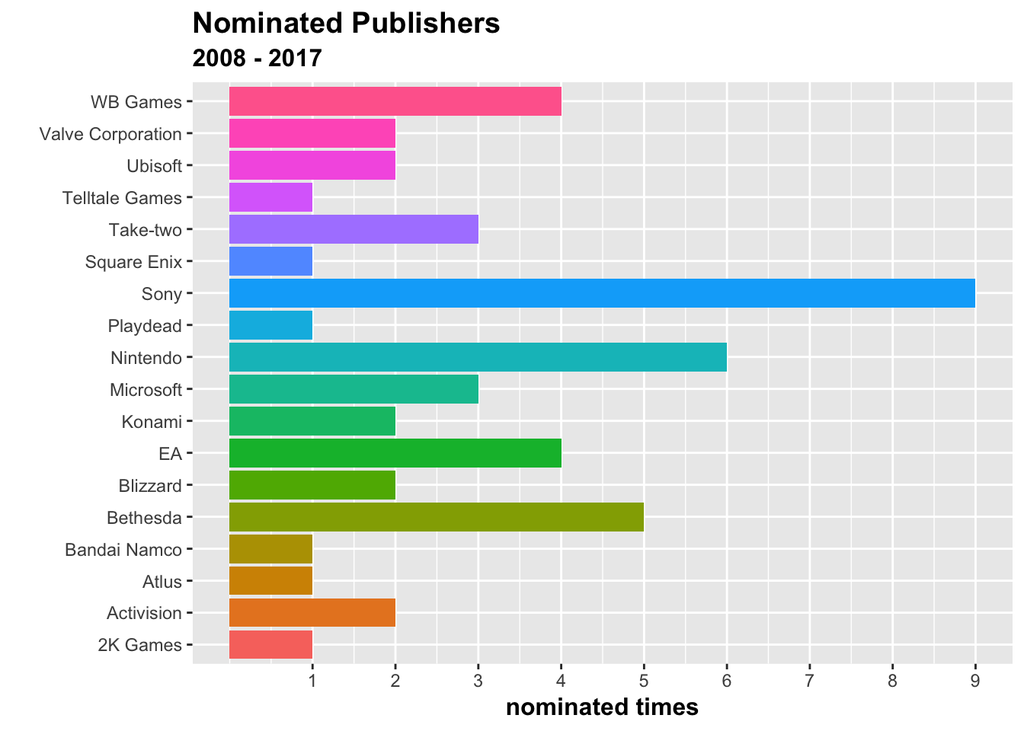

```r
# publisher plot
publisher = ggplot(goty.data, aes(Publisher, fill = Publisher)) +
  geom_bar() +
  guides(fill = FALSE) +
  xlab("") +
  ylab("nominated times") +
  scale_y_continuous(breaks = c(1:12)) +
  coord_flip() +
  ggtitle("Nominated Publishers", subtitle = "2008 - 2017") +
  theme(title = element_text(face = "bold", size = 12))

print(publisher)
```

In this chart we can see for publisher who is also hardware developer has more nominated games than others. For example: Sony, Nintendo and Microsoft. Also we can see Bethesda rand 3rd in the chart, which is the best for content-only publishers.

#### Gamingtime Comparison

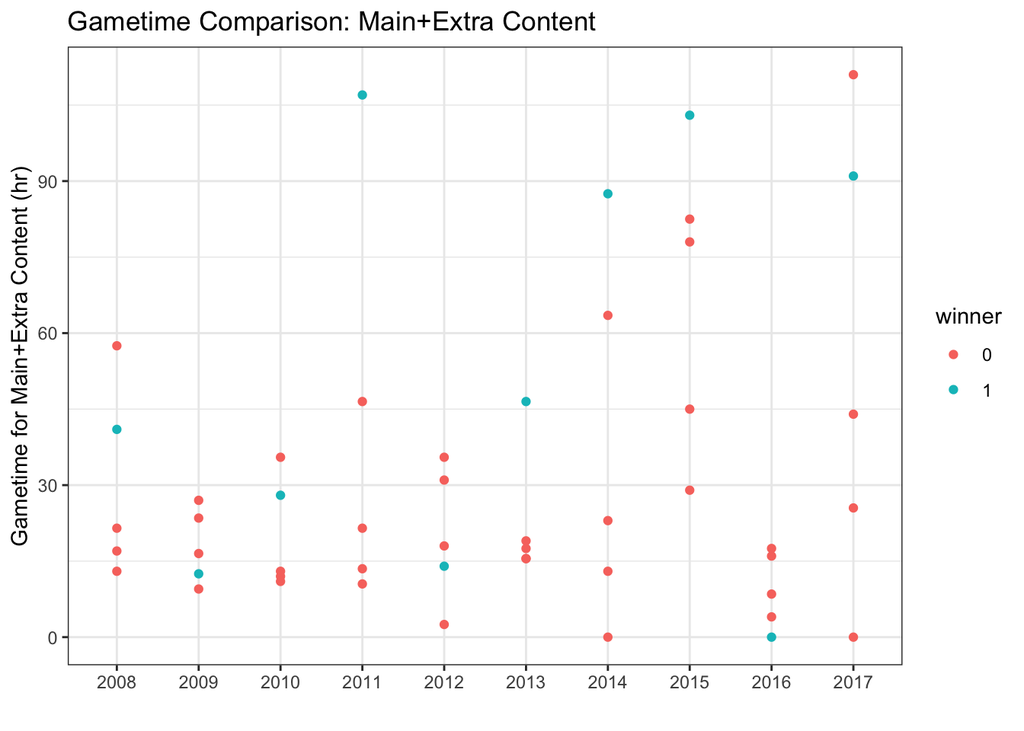

```r
# game time plot
normal.time = ggplot(goty.data, aes(x = Year, y = Gametime_main.extra, color = winner)) +
  geom_point() +
  scale_color_discrete() +
  theme_bw() +
  ggtitle("Gametime Comparison: Main+Extra Content") +
  ylab("Gametime for Main+Extra Content (hr)") +
  xlab("")

extra.time = ggplot(goty.data, aes(x = Year, y = time.diff, color = winner)) +
  geom_point() +
  scale_color_discrete() +
  theme_bw() +
  ggtitle("Gametime Comparison: Extra Content") +
  ylab("Gametime for Extra Content (hr)") +
  xlab("")

print(normal.time)
```

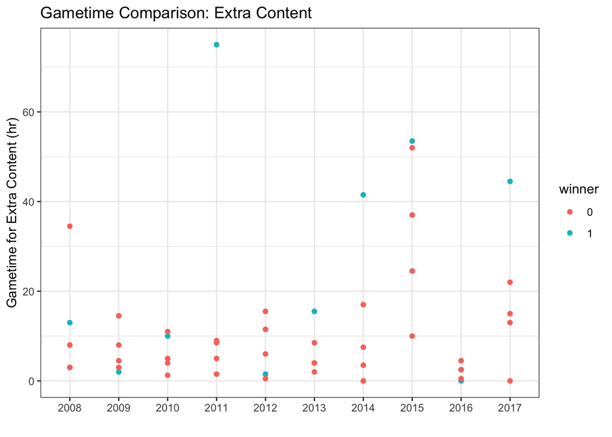

```r
print(extra.time)
```

#### Gamingtime vs. Critics’ Review Numbers/Ratings

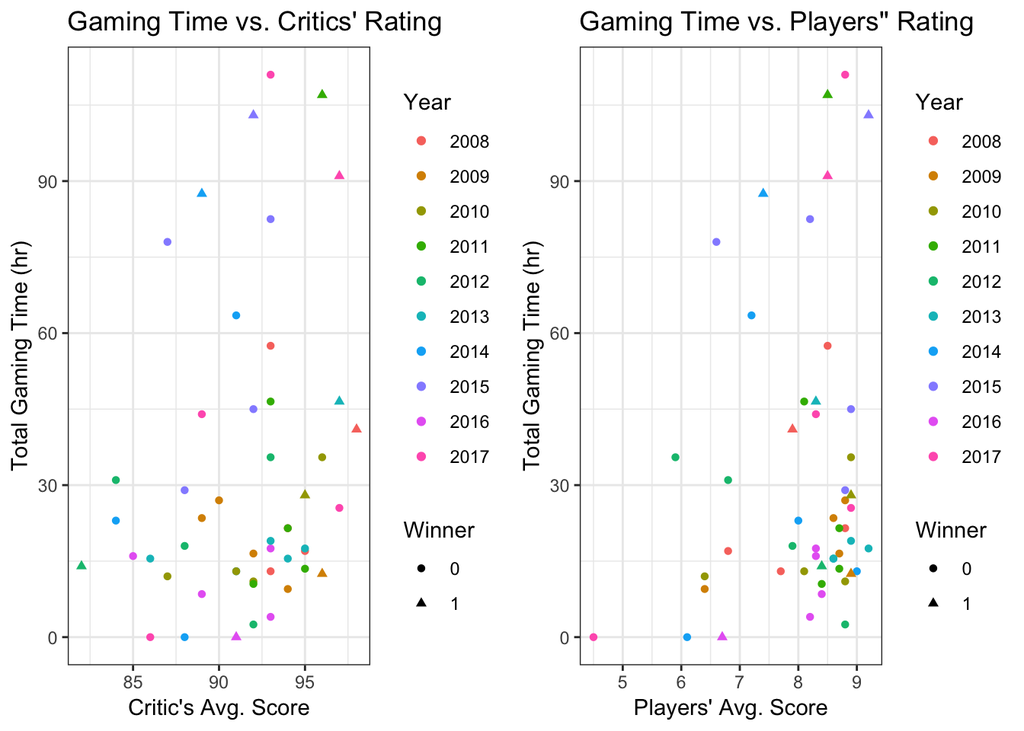

```r
gametime.critic = ggplot(gametime.plot, aes(x = crino, y = GamingTime, color = Year, shape = Winner)) +
  geom_point() +
  theme_bw() +
  xlab("Critic's Avg. Score") +
  ylab("Total Gaming Time (hr)") +
  ggtitle("Gaming Time vs. Critics' Rating")

gametime.player = ggplot(gametime.plot, aes(x = playno, y = GamingTime, color = Year, shape = Winner)) +
  geom_point() +
  theme_bw()  +
  xlab("Players' Avg. Score") +
  ylab("Total Gaming Time (hr)") +
  ggtitle("Gaming Time vs. Players'' Rating")

multiplot(gametime.critic, gametime.player, cols = 2)
```

#### Critic’s vs. Players’

We can understand by the two graphs that critic’s perspective may not meet players’ perception.

**WordCloud for Critics’ Reviews**

```r
critic.cloud = colSums(critic != 0)
critic.cloud = data_frame(Word = names(critic.cloud), count = critic.cloud)
critic.pass = critic.cloud[critic.cloud$count > 10, ]
wordcloud2(critic.pass[1:600, ])
```

[interactive chart not shown]

**Wordcloud for Players’ Reviews**

```r
player.cloud = colSums(player != 0)
player.cloud = data_frame(Word = names(player.cloud), count = player.cloud)
player.pass = player.cloud[player.cloud$count > 10, ]
wordcloud2(player.pass[1:600, ])
```

[interactive chart not shown]

> Here we choose words that have non-zero tfidf for more than 10 games

### Cluster Analysis

Here we try 2 approaches to do the analysis: `hierarchical` & `kmeans` clustering. * For the quantitative data, we scaled them first before we create distance matrix. * For the text mining data, we first perform PCA to reduce the dimension.

The details will be specify in the following sections.

```r
# data pre-processing: quantitive data
game.cluster = as.matrix(goty.data[ ,10:15])
game.cluster = matrix(as.numeric(unlist(game.cluster)), nrow = nrow(game.cluster))
game.cluster = scale(game.cluster)
row.names(game.cluster) = goty.data$Game

critic.cluster = as.matrix(goty.score[ ,3:7])
critic.cluster = scale(critic.cluster)
row.names(critic.cluster) = goty.score$Game

player.cluster = as.matrix(goty.score[ ,8:12])
player.cluster = scale(player.cluster)
row.names(player.cluster) = goty.score$Game
```

> The date should be scale first for creating distant matrix

#### PCA Selection - Qualitative Data

```r
# pca for critics review
crireview.cluster = as.matrix(critic[ ,2:10298])
crireview.pca = prcomp(crireview.cluster)
summary(crireview.pca) # pca = 34 -> 85%
```

```
## Importance of components:
##                            PC1     PC2     PC3     PC4     PC5     PC6
## Standard deviation     0.02264 0.01944 0.01920 0.01905 0.01836 0.01784
## Proportion of Variance 0.06119 0.04513 0.04401 0.04331 0.04024 0.03797
## Cumulative Proportion  0.06119 0.10632 0.15033 0.19364 0.23388 0.27185
##                            PC7     PC8     PC9    PC10    PC11   PC12
## Standard deviation     0.01761 0.01750 0.01730 0.01626 0.01550 0.0154
## Proportion of Variance 0.03703 0.03656 0.03573 0.03156 0.02866 0.0283
## Cumulative Proportion  0.30887 0.34543 0.38117 0.41272 0.44138 0.4697
##                           PC13    PC14    PC15    PC16    PC17    PC18
## Standard deviation     0.01511 0.01496 0.01395 0.01368 0.01324 0.01307
## Proportion of Variance 0.02724 0.02670 0.02323 0.02232 0.02093 0.02038
## Cumulative Proportion  0.49692 0.52363 0.54686 0.56918 0.59011 0.61049
##                           PC19    PC20    PC21    PC22    PC23    PC24
## Standard deviation     0.01282 0.01237 0.01225 0.01199 0.01174 0.01161
## Proportion of Variance 0.01961 0.01825 0.01792 0.01716 0.01646 0.01609
## Cumulative Proportion  0.63011 0.64836 0.66628 0.68343 0.69989 0.71598
##                           PC25    PC26    PC27    PC28    PC29    PC30
## Standard deviation     0.01149 0.01125 0.01119 0.01108 0.01099 0.01092
## Proportion of Variance 0.01577 0.01511 0.01494 0.01466 0.01443 0.01422
## Cumulative Proportion  0.73175 0.74686 0.76180 0.77646 0.79089 0.80511
##                           PC31    PC32    PC33    PC34    PC35     PC36
## Standard deviation     0.01070 0.01047 0.01023 0.01018 0.01004 0.009966
## Proportion of Variance 0.01365 0.01308 0.01249 0.01237 0.01203 0.011860
## Cumulative Proportion  0.81877 0.83185 0.84435 0.85671 0.86875 0.880600
##                            PC37     PC38     PC39     PC40     PC41
## Standard deviation     0.009766 0.009561 0.009348 0.009219 0.009097
## Proportion of Variance 0.011380 0.010910 0.010430 0.010140 0.009880
## Cumulative Proportion  0.891990 0.902900 0.913330 0.923470 0.933350
##                            PC42    PC43     PC44     PC45     PC46    PC47
## Standard deviation     0.008746 0.00869 0.008616 0.008495 0.008388 0.00807
## Proportion of Variance 0.009130 0.00901 0.008860 0.008610 0.008400 0.00777
## Cumulative Proportion  0.942480 0.95149 0.960350 0.968960 0.977360 0.98513
##                            PC48     PC49      PC50
## Standard deviation     0.008004 0.007777 3.747e-16
## Proportion of Variance 0.007650 0.007220 0.000e+00
## Cumulative Proportion  0.992780 1.000000 1.000e+00
```

```r
# player cluster
plreview.cluster = as.matrix(player[ ,2:25262])
plreview.pca = prcomp(plreview.cluster)
summary(plreview.pca) # pca 34 -> 85%
```

```
## Importance of components:
##                            PC1     PC2     PC3     PC4     PC5     PC6
## Standard deviation     0.01163 0.01129 0.01088 0.01064 0.01055 0.01015
## Proportion of Variance 0.04845 0.04568 0.04235 0.04055 0.03985 0.03691
## Cumulative Proportion  0.04845 0.09413 0.13648 0.17703 0.21688 0.25379
##                             PC7      PC8      PC9     PC10     PC11
## Standard deviation     0.009776 0.009713 0.009436 0.009356 0.008875
## Proportion of Variance 0.034220 0.033790 0.031880 0.031350 0.028200
## Cumulative Proportion  0.288010 0.321800 0.353680 0.385030 0.413230
##                            PC12     PC13     PC14     PC15     PC16
## Standard deviation     0.008777 0.008665 0.008556 0.008534 0.008508
## Proportion of Variance 0.027590 0.026890 0.026210 0.026080 0.025920
## Cumulative Proportion  0.440820 0.467710 0.493920 0.520000 0.545920
##                           PC17     PC18     PC19    PC20     PC21     PC22
## Standard deviation     0.00842 0.008107 0.007827 0.00750 0.007256 0.007101
## Proportion of Variance 0.02539 0.023530 0.021930 0.02014 0.018850 0.018060
## Cumulative Proportion  0.57130 0.594830 0.616770 0.63691 0.655760 0.673820
##                            PC23    PC24     PC25     PC26     PC27
## Standard deviation     0.006924 0.00683 0.006747 0.006701 0.006536
## Proportion of Variance 0.017170 0.01670 0.016300 0.016080 0.015300
## Cumulative Proportion  0.690990 0.70769 0.723990 0.740070 0.755370
##                            PC28    PC29     PC30     PC31     PC32
## Standard deviation     0.006498 0.00645 0.006383 0.006178 0.006087
## Proportion of Variance 0.015120 0.01490 0.014590 0.013670 0.013270
## Cumulative Proportion  0.770490 0.78539 0.799980 0.813640 0.826910
##                            PC33     PC34    PC35     PC36     PC37
## Standard deviation     0.005976 0.005958 0.00593 0.005907 0.005824
## Proportion of Variance 0.012790 0.012710 0.01259 0.012490 0.012150
## Cumulative Proportion  0.839700 0.852410 0.86500 0.877500 0.889640
##                            PC38     PC39     PC40    PC41     PC42    PC43
## Standard deviation     0.005777 0.005733 0.005672 0.00558 0.005556 0.00543
## Proportion of Variance 0.011950 0.011770 0.011520 0.01115 0.011060 0.01056
## Cumulative Proportion  0.901590 0.913360 0.924880 0.93603 0.947080 0.95764
##                            PC44     PC45    PC46     PC47     PC48
## Standard deviation     0.005294 0.005021 0.00494 0.004657 0.004355
## Proportion of Variance 0.010040 0.009030 0.00874 0.007770 0.006790
## Cumulative Proportion  0.967680 0.976710 0.98544 0.993210 1.000000
##                             PC49     PC50
## Standard deviation     5.563e-16 9.68e-19
## Proportion of Variance 0.000e+00 0.00e+00
## Cumulative Proportion  1.000e+00 1.00e+00
```

> Here we choose 34 PCA for both critics and players to retain at least 85% of variation

#### Approach 1: K-means

First we check with elbow plots to decide on the k-value:

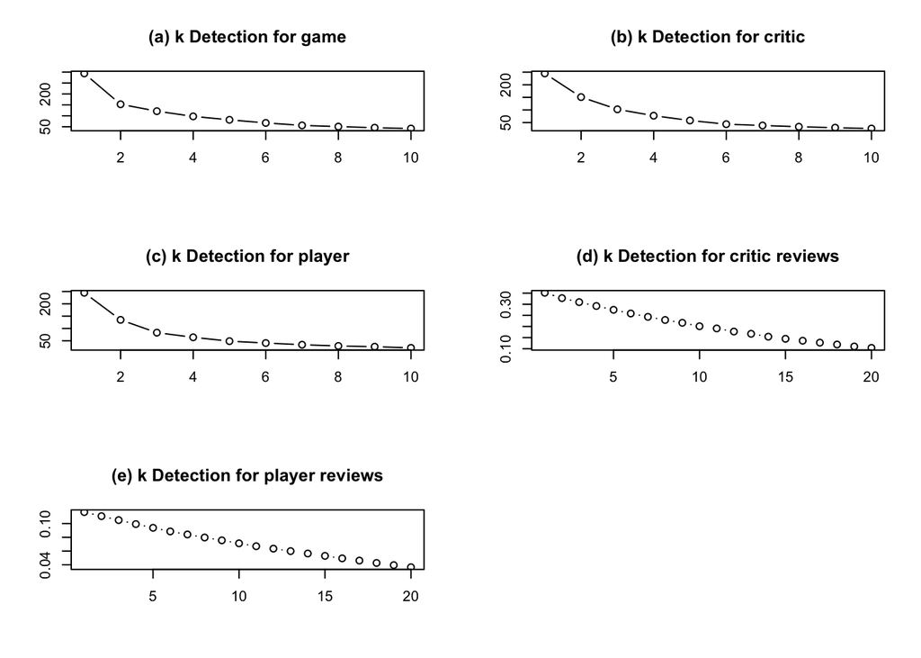

```r
# a: game kmeans
wss = c()
for(i in 1:10) {
  kout = kmeans(game.cluster, centers = i, nstart = 20)
  wss[i] = kout$tot.withinss
}

# b: critic kmeans
wss1 = c()
for(i in 1:10) {
  kout = kmeans(critic.cluster, centers = i, nstart = 20)
  wss1[i] = kout$tot.withinss
}

# c: player kmeans
wss2 = c()
for(i in 1:10) {
  kout = kmeans(player.cluster, centers = i, nstart = 20)
  wss2[i] = kout$tot.withinss
}

# d: critic review kmeans
wss3 = c()
for(i in 1:20) {
  kout = kmeans(crireview.pca$x[ ,1:34], centers = i, nstart = 20)
  wss3[i] = kout$tot.withinss
}

# e: player review kmeans
wss4 = c()
for(i in 1:20) {
  kout = kmeans(plreview.pca$x[ ,1:34], centers = i, nstart = 20)
  wss4[i] = kout$tot.withinss
}

# plot
par(mfrow = c(3,2))

plot(1:10, wss, xlab = "", ylab = "", main = "(a) k Detection for game", type = "b")
plot(1:10, wss1, xlab = "", ylab = "", main = "(b) k Detection for critic", type = "b")
plot(1:10, wss2, xlab = "", ylab = "", main = "(c) k Detection for player", type = "b")
plot(1:20, wss3, ylab = "", xlab = "", main = "(d) k Detection for critic reviews", type = "b")
plot(1:20, wss4, ylab = "", xlab = "", main = "(e) k Detection for player reviews", type = "b")
```

Here we choose k = 4 for quantitative data. As for quantitative data(text based), we cannot see suitable k for us to choose from. Therefore, we would not perform kmeans for these two dataset.

**Cluster by Nature & Attrubutes of the Game**

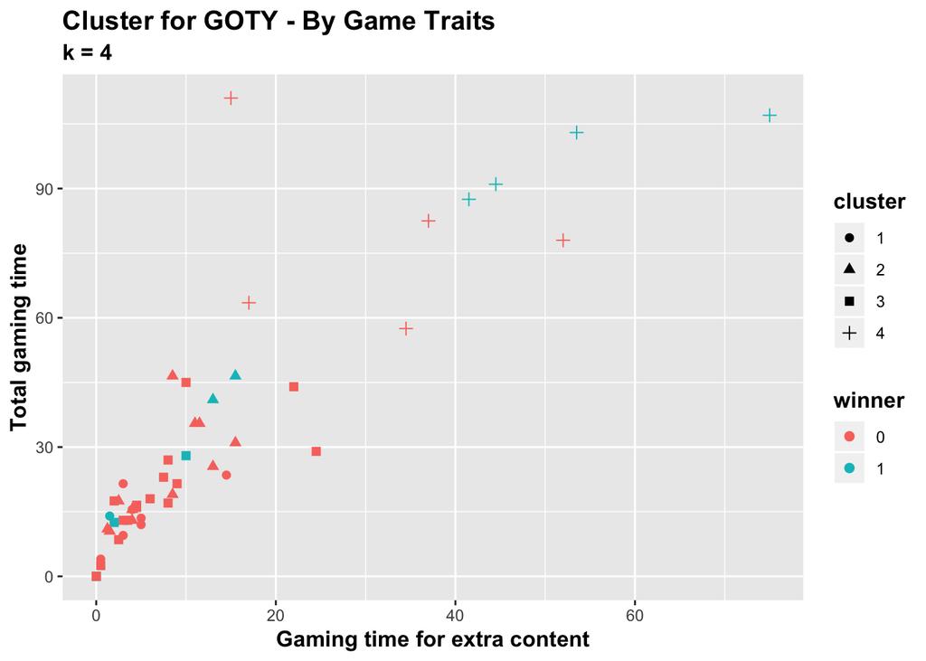

```r
game.kmean = kmeans(game.cluster, centers = 4, nstart = 20)
game.final = data.frame(game = goty.data$Game, x = goty.data$time.diff, y = goty.data$Gametime_main.extra, cluster = game.kmean$cluster, winner = goty.data$winner)
game.final$cluster = as.factor(game.final$cluster)

game.cluster.plot = ggplot(game.final, aes(x = x, y = y, shape = cluster)) +
  geom_point(aes(color = winner), size = 2) +
  ggtitle("Cluster for GOTY - By Game Traits", subtitle = "k = 4") +
  xlab("Gaming time for extra content") +
  ylab("Total gaming time") +
  theme(title = element_text(size = 12, face = "bold"))

print(game.cluster.plot)
```

**Cluster by Critics’ Ratings**

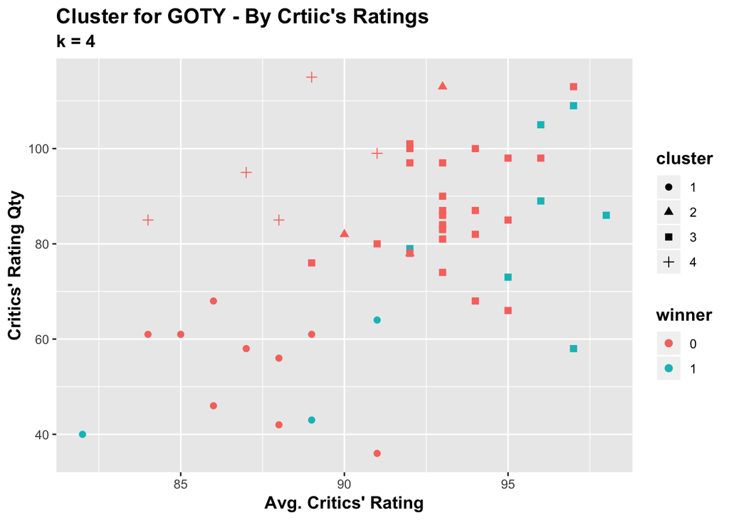

```r
# ratings
critic.kmean = kmeans(critic.cluster, centers = 4, nstart = 20)
critic.final = data.frame(game = goty.data$Game, x = goty.score$Critic_score, y = goty.score$Critic_total, cluster = critic.kmean$cluster, winner = goty.data$winner)
critic.final$cluster = as.factor(critic.final$cluster)

critic.cluster.plot = ggplot(critic.final, aes(x = x, y = y, shape = cluster)) +
  geom_point(aes(color = winner), size = 2) +
  ggtitle("Cluster for GOTY - By Crtiic's Ratings", subtitle = "k = 4") +
  xlab("Avg. Critics' Rating") +
  ylab("Critics' Rating Qty") +
  theme(title = element_text(size = 12, face = "bold"))

print(critic.cluster.plot)
```

**Cluster by Players’ Ratings**

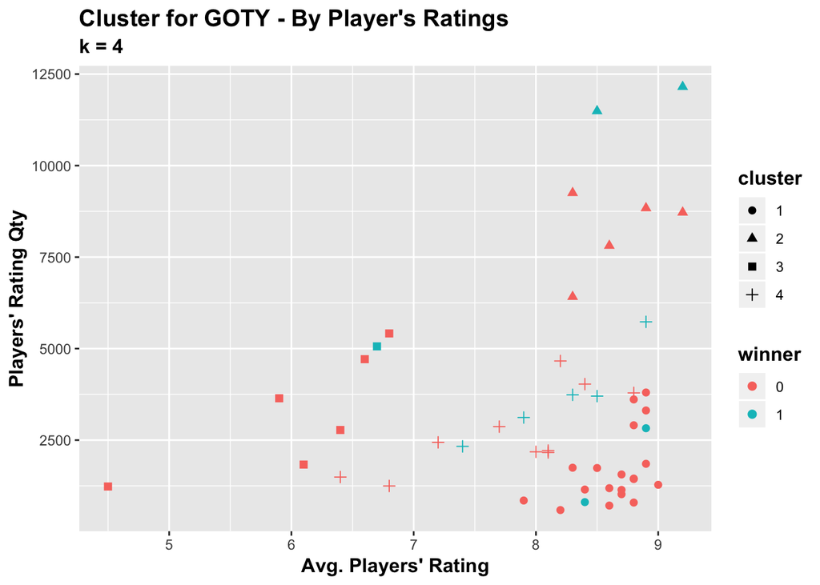

```r
player.kmean = kmeans(player.cluster, centers = 4, nstart = 20)
player.final = data.frame(game = goty.data$Game, x = goty.score$Player_score, y = goty.score$Player_total, cluster = player.kmean$cluster, winner = goty.data$winner)
player.final$cluster = as.factor(player.final$cluster)

player.cluster.plot = ggplot(player.final, aes(x = x, y = y, shape = cluster)) +
  geom_point(aes(color = winner), size = 2) +
  ggtitle("Cluster for GOTY - By Player's Ratings", subtitle = "k = 4") +
  xlab("Avg. Players' Rating") +
  ylab("Players' Rating Qty") +
  theme(title = element_text(size = 12, face = "bold"))

print(player.cluster.plot)
```

We can see goty are not always considered the “best” for players.

#### Approach 2: Hierarchical

We use `euclidean` combined with `complete` method to calculate the distance. Then we plot dendrograms to visualize the results.

**Cluster by Nature & Attrubutes of the Game**

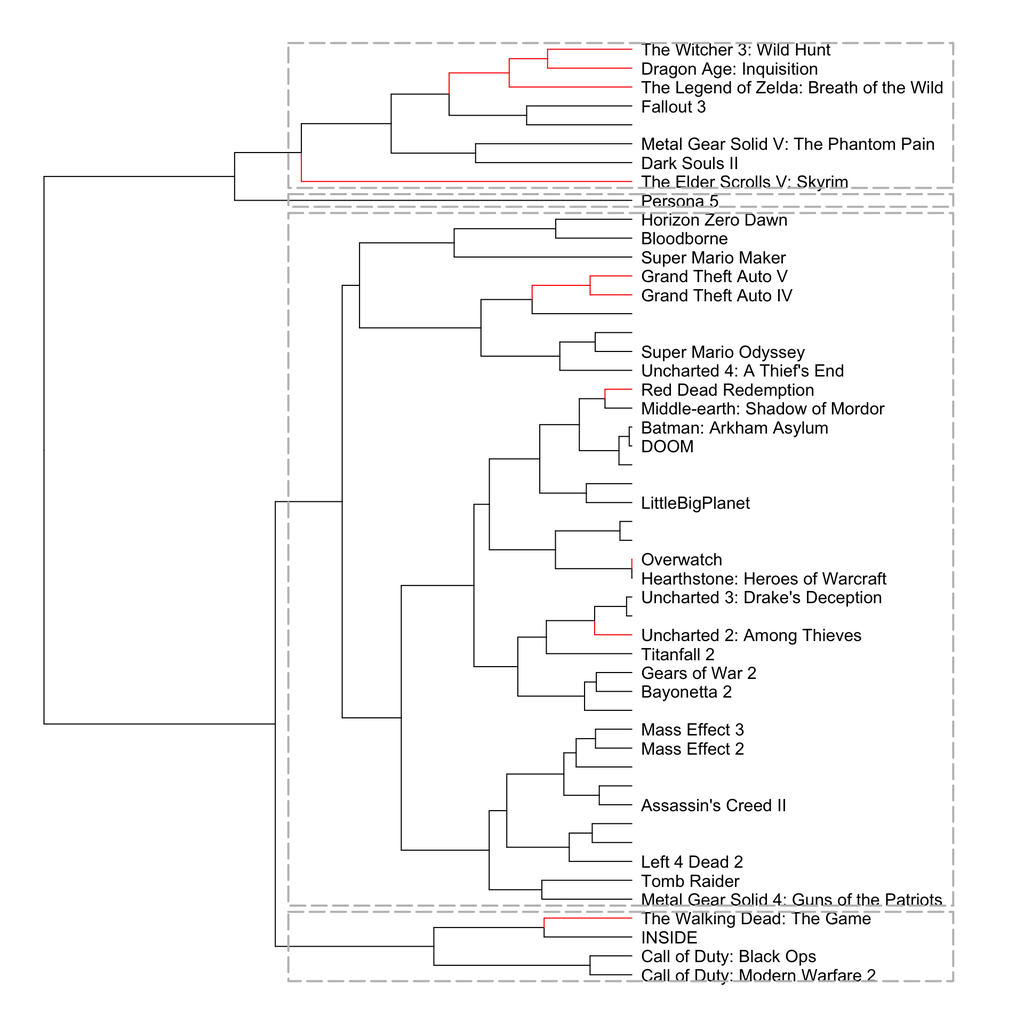

```r
game.hclust.pr = hclust(dist(game.cluster))
game.hcd = as.dendrogram(game.hclust.pr)
game.hcd = game.hcd %>% branches_attr_by_labels(winners, color = "red")
par(mar=c(0.1,1,0.1,18))
plot(game.hcd,axes= FALSE, horiz = TRUE)
game.hcd %>% rect.dendrogram(k = 4, horiz = TRUE, border = 8, lty = 5, lwd = 2)
```

We can cut this dendrogram into 4 cluster. The uppermost are the ones come from big publisher and also have long gaming time. In other words, the games in this cluster are considered the “Big Project” for their publisher in that yaer. The cluster in the very end are games which come from third-tier publishers with shorter gaming time and less extra content.

**Cluster by Critics’ Ratings/Reviews**

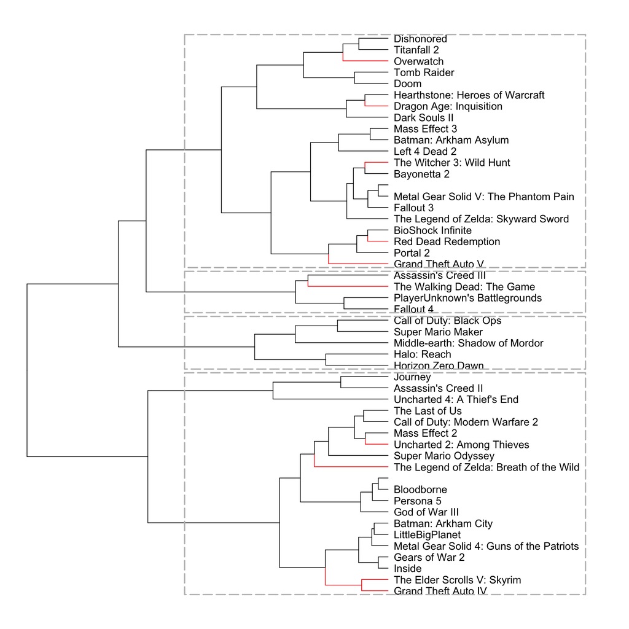

```r
critic.hclust.pr = hclust(dist(critic.cluster))
critic.hcd = as.dendrogram(critic.hclust.pr)
critic.hcd = branches_attr_by_labels(critic.hcd, winners, color = "red")
par(mar=c(0.8,1,0.8,18))
plot(critic.hcd,axes= FALSE, horiz = TRUE)
critic.hcd %>% rect.dendrogram(k = 4, horiz = TRUE, border = 8, lty = 5, lwd = 2)
```

If we cut the dendrogram into four clusters, games in the lowest end like GTA 4, The Elder Scroll V…etc. recieved high ratings and also reviewd by lots of critics. The 2 clusters in the middle are games which have more mixed rating, indicating that these games recieved more conflicted reviews. The topmost cluster are games which have higher percentage of positive feedback among all ratings.

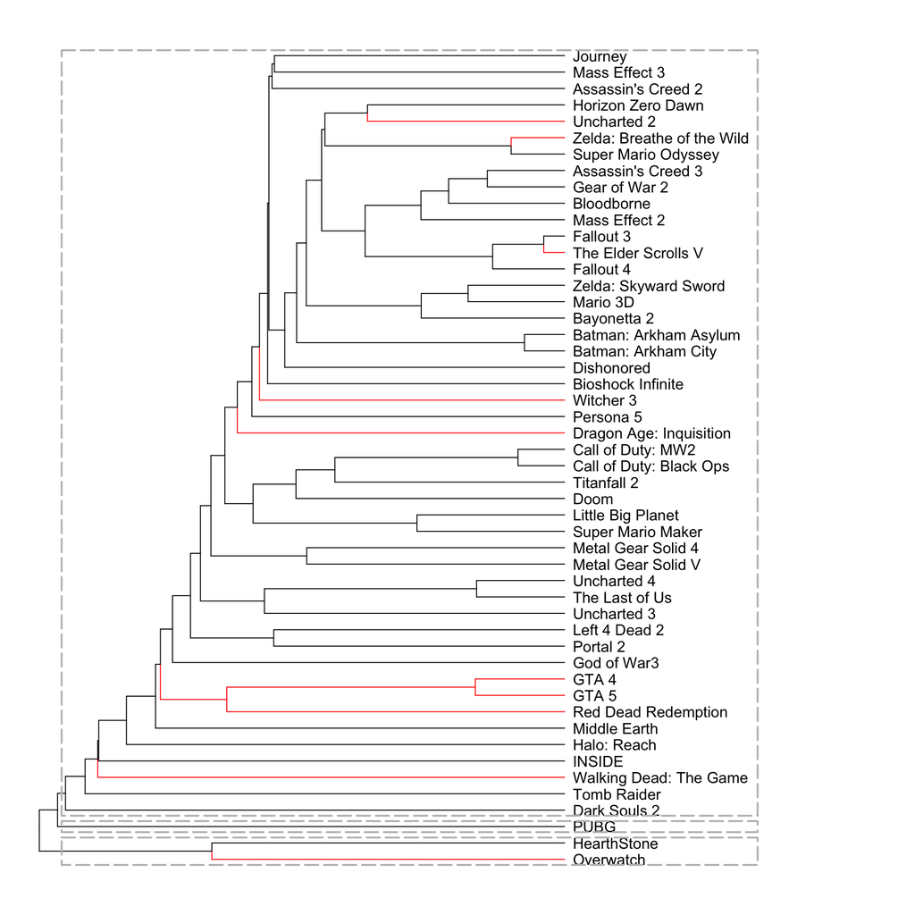

```r
crireview.hclust.pr = hclust(dist(crireview.pca$x[1:50 ,1:34]))
crireview.hcd = as.dendrogram(crireview.hclust.pr)
crireview.hcd = branches_attr_by_labels(crireview.hcd, winners2, color = "red")
par(mar=c(0.8,1,0.8,18))
plot(crireview.hcd,axes= FALSE, horiz = TRUE)
crireview.hcd %>% rect.dendrogram(k = 3, horiz = TRUE, border = 8, lty = 5, lwd = 2)
```

This cluster basically make games from the same series or publishers in near position. Therefore, we may indicate that critics tend to use similar words to describe sequel games. Also, we can see the used-term difference between traditional video games(high cost, single player, scripted) and online games like Hearthstone, PUBG…

**Cluster by Players’ Ratings/Reviews**

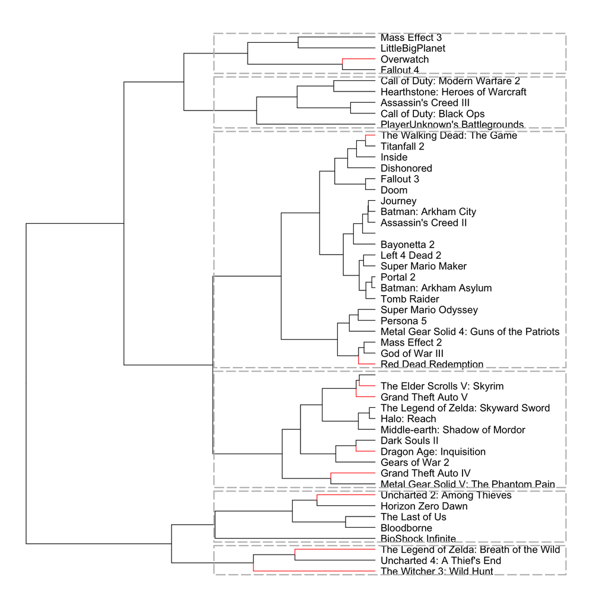

```r
player.hclust.pr = hclust(dist(player.cluster))
player.hcd = as.dendrogram(player.hclust.pr)
player.hcd = branches_attr_by_labels(player.hcd, winners, color = "red")
par(mar=c(0.8,1,0.8,18))
plot(player.hcd,axes= FALSE, horiz = TRUE)
player.hcd %>% rect.dendrogram(k = 6, horiz = TRUE, border = 8, lty = 5, lwd = 2)
```

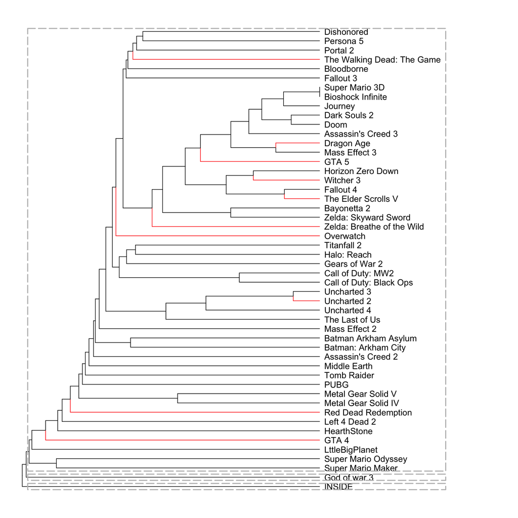

```r
plreview.hclust.pr = hclust(dist(plreview.pca$x[ ,1:34]))
plreview.hcd = as.dendrogram(plreview.hclust.pr)
plreview.hcd = branches_attr_by_labels(plreview.hcd, winners1, color = "red")
par(mar=c(0.8,1,0.8,18))
plot(plreview.hcd,axes= FALSE, horiz = TRUE)
plreview.hcd %>% rect.dendrogram(k = 3, horiz = TRUE, border = 8, lty = 5, lwd = 2)
```

From the perspective of players review, we can see games with similar genre(ex: shooting) tned to be in the nearby position.

### Cluster Comparison & Conclusion

```r
game.compare = cutree(game.hclust.pr, k = 4)
critic.compare = cutree(critic.hclust.pr, k = 4)
player.compare = cutree(player.hclust.pr, k = 4)
crireview.compare = cutree(crireview.hclust.pr, k = 3)
plreview.compare = cutree(plreview.hclust.pr, k = 3)

table(game.compare, critic.compare)
```

```
##             critic.compare
## game.compare  1  2  3  4
##            1  5  0  2  1
##            2 16  4 15  2
##            3  0  1  2  1
##            4  0  0  1  0
```

```r
table(game.compare, player.compare)
```

```
##             player.compare
## game.compare  1  2  3  4
##            1  5  1  2  0
##            2 25  6  1  5
##            3  2  2  0  0
##            4  1  0  0  0
```

```r
table(critic.compare, player.compare)
```

```
##               player.compare
## critic.compare  1  2  3  4
##              1 16  3  1  1
##              2  3  1  0  1
##              3 13  2  2  3
##              4  1  3  0  0
```

```r
table(game.compare, crireview.compare)
```

```
##             crireview.compare
## game.compare  1  2  3
##            1  7  0  1
##            2 35  2  0
##            3  4  0  0
##            4  1  0  0
```

```r
table(game.compare, plreview.compare)
```

```
##             plreview.compare
## game.compare  1  2  3
##            1  7  0  1
##            2 36  1  0
##            3  4  0  0
##            4  1  0  0
```

```r
table(crireview.compare, plreview.compare)
```

```
##                  plreview.compare
## crireview.compare  1  2  3
##                 1 45  1  1
##                 2  2  0  0
##                 3  1  0  0
```